# (Loan Data from Prosper Exploration )

## Preliminary Wrangling

> This data set contains 113,937 loans with 81 variables on each loan, including loan amount, borrower rate (or interest rate), current loan status, borrower income, and many others. This data [dictionary](https://docs.google.com/spreadsheets/d/1gDyi_L4UvIrLTEC6Wri5nbaMmkGmLQBk-Yx3z0XDEtI/edit#gid=0) explains the variables in the data set.

```python
# import all packages and set plots to be embedded inline
import numpy as np
import pandas as pd
import matplotlib.pyplot as plt
import seaborn as sns
import warnings
warnings.filterwarnings('ignore')

%matplotlib inline
```

```python
# Load data
df = pd.read_csv("prosperLoanData.csv")
```

```python
df.head()
```

|  | ListingKey | ListingNumber | ListingCreationDate | CreditGrade | Term | LoanStatus | ClosedDate | BorrowerAPR | BorrowerRate | LenderYield | ... | LP_ServiceFees | LP_CollectionFees | LP_GrossPrincipalLoss | LP_NetPrincipalLoss | LP_NonPrincipalRecoverypayments | PercentFunded | Recommendations | InvestmentFromFriendsCount | InvestmentFromFriendsAmount | Investors |
| --- | --- | --- | --- | --- | --- | --- | --- | --- | --- | --- | --- | --- | --- | --- | --- | --- | --- | --- | --- | --- | --- |
| 0 | 1021339766868145413AB3B | 193129 | 2007-08-26 19:09:29.263000000 | C | 36 | Completed | 2009-08-14 00:00:00 | 0.16516 | 0.1580 | 0.1380 | ... | -133.18 | 0.0 | 0.0 | 0.0 | 0.0 | 1.0 | 0 | 0 | 0.0 | 258 |
| 1 | 10273602499503308B223C1 | 1209647 | 2014-02-27 08:28:07.900000000 | NaN | 36 | Current | NaN | 0.12016 | 0.0920 | 0.0820 | ... | 0.00 | 0.0 | 0.0 | 0.0 | 0.0 | 1.0 | 0 | 0 | 0.0 | 1 |
| 2 | 0EE9337825851032864889A | 81716 | 2007-01-05 15:00:47.090000000 | HR | 36 | Completed | 2009-12-17 00:00:00 | 0.28269 | 0.2750 | 0.2400 | ... | -24.20 | 0.0 | 0.0 | 0.0 | 0.0 | 1.0 | 0 | 0 | 0.0 | 41 |
| 3 | 0EF5356002482715299901A | 658116 | 2012-10-22 11:02:35.010000000 | NaN | 36 | Current | NaN | 0.12528 | 0.0974 | 0.0874 | ... | -108.01 | 0.0 | 0.0 | 0.0 | 0.0 | 1.0 | 0 | 0 | 0.0 | 158 |
| 4 | 0F023589499656230C5E3E2 | 909464 | 2013-09-14 18:38:39.097000000 | NaN | 36 | Current | NaN | 0.24614 | 0.2085 | 0.1985 | ... | -60.27 | 0.0 | 0.0 | 0.0 | 0.0 | 1.0 | 0 | 0 | 0.0 | 20 |

5 rows × 81 columns

### What is the structure of your dataset?

```python
df.shape # 113937 row, and 81 colunms
```

```
(113937, 81)
```

```python
df.info()
```

```
<class 'pandas.core.frame.DataFrame'>
RangeIndex: 113937 entries, 0 to 113936
Data columns (total 81 columns):
ListingKey                             113937 non-null object
ListingNumber                          113937 non-null int64
ListingCreationDate                    113937 non-null object
CreditGrade                            28953 non-null object
Term                                   113937 non-null int64
LoanStatus                             113937 non-null object
ClosedDate                             55089 non-null object
BorrowerAPR                            113912 non-null float64
BorrowerRate                           113937 non-null float64
LenderYield                            113937 non-null float64
EstimatedEffectiveYield                84853 non-null float64
EstimatedLoss                          84853 non-null float64
EstimatedReturn                        84853 non-null float64
ProsperRating (numeric)                84853 non-null float64
ProsperRating (Alpha)                  84853 non-null object
ProsperScore                           84853 non-null float64
ListingCategory (numeric)              113937 non-null int64
BorrowerState                          108422 non-null object
Occupation                             110349 non-null object
EmploymentStatus                       111682 non-null object
EmploymentStatusDuration               106312 non-null float64
IsBorrowerHomeowner                    113937 non-null bool
CurrentlyInGroup                       113937 non-null bool
GroupKey                               13341 non-null object
DateCreditPulled                       113937 non-null object
CreditScoreRangeLower                  113346 non-null float64
CreditScoreRangeUpper                  113346 non-null float64
FirstRecordedCreditLine                113240 non-null object
CurrentCreditLines                     106333 non-null float64
OpenCreditLines                        106333 non-null float64
TotalCreditLinespast7years             113240 non-null float64
OpenRevolvingAccounts                  113937 non-null int64
OpenRevolvingMonthlyPayment            113937 non-null float64
InquiriesLast6Months                   113240 non-null float64
TotalInquiries                         112778 non-null float64
CurrentDelinquencies                   113240 non-null float64
AmountDelinquent                       106315 non-null float64
```

[output cut: 31 more lines]

```
LP_CustomerPayments                    113937 non-null float64
LP_CustomerPrincipalPayments           113937 non-null float64
LP_InterestandFees                     113937 non-null float64
LP_ServiceFees                         113937 non-null float64
LP_CollectionFees                      113937 non-null float64
LP_GrossPrincipalLoss                  113937 non-null float64
LP_NetPrincipalLoss                    113937 non-null float64
LP_NonPrincipalRecoverypayments        113937 non-null float64
PercentFunded                          113937 non-null float64
Recommendations                        113937 non-null int64
InvestmentFromFriendsCount             113937 non-null int64
InvestmentFromFriendsAmount            113937 non-null float64
Investors                              113937 non-null int64
dtypes: bool(3), float64(50), int64(11), object(17)
memory usage: 68.1+ MB
```

```python
df.describe()
```

|  | ListingNumber | Term | BorrowerAPR | BorrowerRate | LenderYield | EstimatedEffectiveYield | EstimatedLoss | EstimatedReturn | ProsperRating (numeric) | ProsperScore | ... | LP_ServiceFees | LP_CollectionFees | LP_GrossPrincipalLoss | LP_NetPrincipalLoss | LP_NonPrincipalRecoverypayments | PercentFunded | Recommendations | InvestmentFromFriendsCount | InvestmentFromFriendsAmount | Investors |
| --- | --- | --- | --- | --- | --- | --- | --- | --- | --- | --- | --- | --- | --- | --- | --- | --- | --- | --- | --- | --- | --- |
| count | 1.139370e+05 | 113937.000000 | 113912.000000 | 113937.000000 | 113937.000000 | 84853.000000 | 84853.000000 | 84853.000000 | 84853.000000 | 84853.000000 | ... | 113937.000000 | 113937.000000 | 113937.000000 | 113937.000000 | 113937.000000 | 113937.000000 | 113937.000000 | 113937.000000 | 113937.000000 | 113937.000000 |
| mean | 6.278857e+05 | 40.830248 | 0.218828 | 0.192764 | 0.182701 | 0.168661 | 0.080306 | 0.096068 | 4.072243 | 5.950067 | ... | -54.725641 | -14.242698 | 700.446342 | 681.420499 | 25.142686 | 0.998584 | 0.048027 | 0.023460 | 16.550751 | 80.475228 |
| std | 3.280762e+05 | 10.436212 | 0.080364 | 0.074818 | 0.074516 | 0.068467 | 0.046764 | 0.030403 | 1.673227 | 2.376501 | ... | 60.675425 | 109.232758 | 2388.513831 | 2357.167068 | 275.657937 | 0.017919 | 0.332353 | 0.232412 | 294.545422 | 103.239020 |
| min | 4.000000e+00 | 12.000000 | 0.006530 | 0.000000 | -0.010000 | -0.182700 | 0.004900 | -0.182700 | 1.000000 | 1.000000 | ... | -664.870000 | -9274.750000 | -94.200000 | -954.550000 | 0.000000 | 0.700000 | 0.000000 | 0.000000 | 0.000000 | 1.000000 |
| 25% | 4.009190e+05 | 36.000000 | 0.156290 | 0.134000 | 0.124200 | 0.115670 | 0.042400 | 0.074080 | 3.000000 | 4.000000 | ... | -73.180000 | 0.000000 | 0.000000 | 0.000000 | 0.000000 | 1.000000 | 0.000000 | 0.000000 | 0.000000 | 2.000000 |
| 50% | 6.005540e+05 | 36.000000 | 0.209760 | 0.184000 | 0.173000 | 0.161500 | 0.072400 | 0.091700 | 4.000000 | 6.000000 | ... | -34.440000 | 0.000000 | 0.000000 | 0.000000 | 0.000000 | 1.000000 | 0.000000 | 0.000000 | 0.000000 | 44.000000 |
| 75% | 8.926340e+05 | 36.000000 | 0.283810 | 0.250000 | 0.240000 | 0.224300 | 0.112000 | 0.116600 | 5.000000 | 8.000000 | ... | -13.920000 | 0.000000 | 0.000000 | 0.000000 | 0.000000 | 1.000000 | 0.000000 | 0.000000 | 0.000000 | 115.000000 |
| max | 1.255725e+06 | 60.000000 | 0.512290 | 0.497500 | 0.492500 | 0.319900 | 0.366000 | 0.283700 | 7.000000 | 11.000000 | ... | 32.060000 | 0.000000 | 25000.000000 | 25000.000000 | 21117.900000 | 1.012500 | 39.000000 | 33.000000 | 25000.000000 | 1189.000000 |

8 rows × 61 columns

### What is/are the main feature(s) of interest in your dataset?

> LoanStatus

### What features in the dataset do you think will help support your investigation into your feature(s) of interest?

> - IncomeRange
> - EmploymentStatus
> - IsBorrowerHomeowner
> - ProsperPrincipalBorrowed
> - LoanOriginalAmount
> - IncomeVerifiable
> - Term
> - ProsperScore
> - Occupation

```python
# I will only inspect the featuers of intrest
df = df [['LoanStatus','IncomeRange','EmploymentStatus','IsBorrowerHomeowner', 'Occupation'
        ,'ProsperPrincipalBorrowed', 'LoanOriginalAmount', 'IncomeVerifiable', 'Term', 'ProsperScore']]
```

```python
# Make a copy to clean things
df_clean = df.copy()
df_clean.info()
```

```
<class 'pandas.core.frame.DataFrame'>
RangeIndex: 113937 entries, 0 to 113936
Data columns (total 10 columns):
LoanStatus                  113937 non-null object
IncomeRange                 113937 non-null object
EmploymentStatus            111682 non-null object
IsBorrowerHomeowner         113937 non-null bool
Occupation                  110349 non-null object
ProsperPrincipalBorrowed    22085 non-null float64
LoanOriginalAmount          113937 non-null int64
IncomeVerifiable            113937 non-null bool
Term                        113937 non-null int64
ProsperScore                84853 non-null float64
dtypes: bool(2), float64(2), int64(2), object(4)
memory usage: 7.2+ MB
```

```python
# check the missing valuse
df_clean.isnull().sum()
```

```
LoanStatus                      0
IncomeRange                     0
EmploymentStatus             2255
IsBorrowerHomeowner             0
Occupation                   3588
ProsperPrincipalBorrowed    91852
LoanOriginalAmount              0
IncomeVerifiable                0
Term                            0
ProsperScore                29084
dtype: int64
```

**We have a total of 113937 rows:**

```
* EmploymentStatus             2255
* Occupation                   3588
* ProsperPrincipalBorrowed    91852 --> to much null, i will drop this colunm
* ProsperScore                29084
```

```python
# drop ProsperPrincipalBorrowed colunm
df_clean.drop(['ProsperPrincipalBorrowed'], axis=1, inplace = True)
```

```python
# drop null rows
df_clean.dropna(inplace = True)
```

```python
# Test if cleand
df_clean.isnull().sum()
```

```
LoanStatus             0
IncomeRange            0
EmploymentStatus       0
IsBorrowerHomeowner    0
Occupation             0
LoanOriginalAmount     0
IncomeVerifiable       0
Term                   0
ProsperScore           0
dtype: int64
```

```python
df_clean.shape
```

```
(83520, 9)
```

## Univariate Exploration

> In this section, I will investigate distributions of individual variables.

```python
# First I will check my target featuer
df_clean.LoanStatus.value_counts()
```

```
Current                   55272
Completed                 19651
Chargedoff                 5336
Defaulted                  1005
Past Due (1-15 days)        798
Past Due (31-60 days)       358
Past Due (61-90 days)       313
Past Due (91-120 days)      304
Past Due (16-30 days)       264
FinalPaymentInProgress      203
Past Due (>120 days)         16
Name: LoanStatus, dtype: int64
```

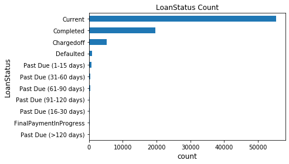

```python
# count plot for loan status
df_clean['LoanStatus'].value_counts()[12::-1].plot(kind='barh')
plt.title('LoanStatus Count', fontsize=12)
plt.xlabel('count', fontsize=12)
plt.ylabel('LoanStatus', fontsize=12)
plt.fontsize = 12
plt.figsize=(12,12)
```

It looks like most borrowers loan statues is current, then completed (which is good), then charged off. I will observe them and see what could be the relation between them and other features.

```python
df_clean.Occupation.value_counts()
```

```
Other                          21317
Professional                   10542
Executive                       3468
Computer Programmer             3236
Teacher                         2888
                               ...
Judge                             22
Student - College Freshman        17
Student - College Sophomore       16
Student - Community College       10
Student - Technical School         2
Name: Occupation, Length: 67, dtype: int64
```

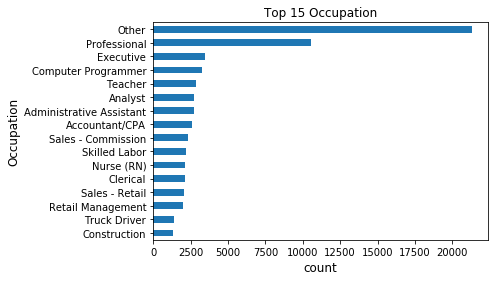

```python
# Take a look at the top 15 occupation
df_clean['Occupation'].value_counts()[15::-1].plot(kind='barh')
plt.title('Top 15 Occupation', fontsize=12)
plt.xlabel('count', fontsize=12)
plt.ylabel('Occupation', fontsize=12)
plt.fontsize = 12
plt.figsize=(12,12)
```

```python
# Creat a dataframe with only the complet loan status
df_complet = df_clean.loc[(df['LoanStatus'].isin(['Completed']))]
```

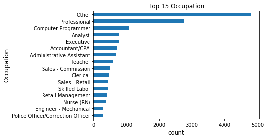

```python
df_complet['Occupation'].value_counts()[15::-1].plot(kind='barh')
plt.title('Top 15 Occupation', fontsize=12)
plt.xlabel('count', fontsize=12)
plt.ylabel('Occupation', fontsize=12)
plt.fontsize = 12
plt.figsize=(12,12)
```

There is defiantly some different in the last 7 occupation

```python
df_clean.Term.value_counts()
```

```
36    57621
60    24286
12     1613
Name: Term, dtype: int64
```

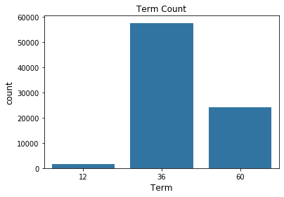

```python
pl = sns.countplot(data = df_clean, x = 'Term', color = sns.color_palette()[0]);
pl.axes.set_title("Term Count",fontsize=12)
pl.set_xlabel("Term",fontsize=12)
pl.set_ylabel("count",fontsize=12);
```

Most borrowers have a loan length of 36 months, next i will check the income range befor moving to Bivariate Exploration

```python
df_clean.IncomeRange.value_counts()
```

```
$50,000-74,999    25293
$25,000-49,999    23574
$100,000+         15166
$75,000-99,999    14401
$1-24,999          4392
Not employed        649
$0                   45
Name: IncomeRange, dtype: int64
```

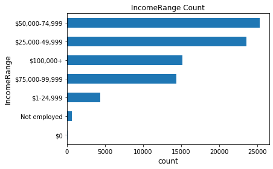

```python
# income range
df_clean['IncomeRange'].value_counts()[15::-1].plot(kind='barh')
plt.title('IncomeRange Count',fontsize=12)
plt.xlabel('count',fontsize=12)
plt.ylabel('IncomeRange',fontsize=12)
plt.fontsize = 12
plt.figsize=(12,12)
```

Most borrower have an incom of $50,000-74,999

### Discuss the distribution(s) of your variable(s) of interest. Were there any unusual points? Did you need to perform any transformations?

> The LoanStatus for most borrower is in the (Current, Completed, and Chargedoff) therefor a good solution is to merge some cases together (for example if a loan is late this mean it is chargegd off) by merging some cases and deleting some we could reach a loan state with two cartagories(eligible, not eligible), this is just an idea. for now i will keep it as it is. most borrowers have a 36 month long loan.

## Bivariate Exploration

> In this section, I will investigate relationships between pairs of variables in the data.

```python
df_clean.dtypes
# Occupation, EmploymentStatus, IncomeRange, LoanStatus --> catagories
```

```
LoanStatus              object
IncomeRange             object
EmploymentStatus        object
IsBorrowerHomeowner       bool
Occupation              object
LoanOriginalAmount       int64
IncomeVerifiable          bool
Term                     int64
ProsperScore           float64
dtype: object
```

```python
def plot_correlation_map( df ):
    corr = df.corr()
    _ , ax = plt.subplots( figsize =( 6 , 12 ) )
    cmap = sns.diverging_palette( 240 , 10 , as_cmap = True )
    plt.title('Correlation Plot')
    _ = sns.heatmap(corr,cmap = cmap,square=True, cbar_kws={ 'shrink' : .41 }, ax=ax, annot = True, annot_kws = { 'fontsize' : 12 })
```

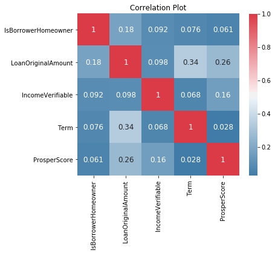

```python
plot_correlation_map(df_clean)
```

a relationship between (term and loanorginamount), (prosperscore and incomeverifiable), (prosperscore and loanorginamount) (isBorrwerHomeOwner and loanorginamount)

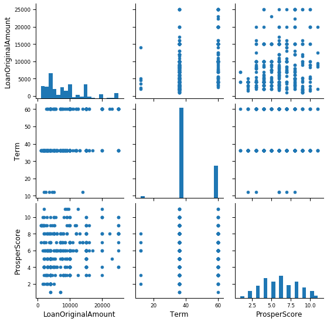

```python
# plot matrix: sample 500  so that plots are clearer and
# they render faster
numeric_vars = ['LoanOriginalAmount','Term', 'ProsperScore']
samples = np.random.choice(df_clean.shape[0], 500, replace = False)
Loan_samp = df_clean.loc[samples,:]
sns.set_context("paper", rc={"font.size":12,"axes.titlesize":12,"axes.labelsize":12})
g = sns.PairGrid(data = Loan_samp, vars = numeric_vars)
g = g.map_diag(plt.hist, bins = 20);
g.map_offdiag(plt.scatter);
```

As expected theres is a small correlation between term and LoanOrginlAmount but it is not that strong. i will do the same thing but i will convert loan status into numbers and see how it corrlete with them

```python
# convert loan statuse to numircal
labels_loanStatus = df_clean['LoanStatus'].astype('category').cat.categories.tolist()
replace_map_loan_status = {'LoanStatus' : {k: v for k,v in zip(labels_loanStatus,list(range(1,len(labels_loanStatus)+1)))}}
print(replace_map_loan_status)
```

```
{'LoanStatus': {'Chargedoff': 1, 'Completed': 2, 'Current': 3, 'Defaulted': 4, 'FinalPaymentInProgress': 5, 'Past Due (1-15 days)': 6, 'Past Due (16-30 days)': 7, 'Past Due (31-60 days)': 8, 'Past Due (61-90 days)': 9, 'Past Due (91-120 days)': 10, 'Past Due (>120 days)': 11}}
```

```python
df_temp = df_clean.copy()
df_temp.replace(replace_map_loan_status, inplace=True)
```

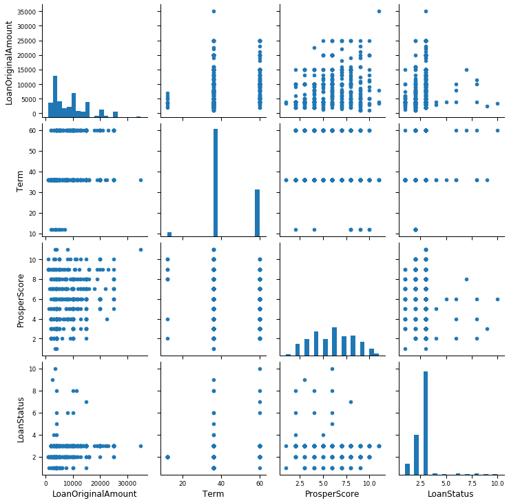

```python
# plot matrix: sample 500  so that plots are clearer and
# they render faster
numeric_vars = ['LoanOriginalAmount','Term', 'ProsperScore', 'LoanStatus']
samples = np.random.choice(df_temp.shape[0], 500, replace = False)
Loan_samp = df_temp.loc[samples,:]
sns.set_context("paper", rc={"font.size":12,"axes.titlesize":12,"axes.labelsize":12})
g = sns.PairGrid(data = Loan_samp, vars = numeric_vars)
g = g.map_diag(plt.hist, bins = 20);
g.map_offdiag(plt.scatter);
```

Okay i think that the properScore is correlated with the loan statuse! i will checck this in the next cell

```python
data_corr = df_temp.corr()
print("Correlation between Loan status and ProsperScore : ",data_corr.loc['LoanStatus','ProsperScore'])
```

```
Correlation between Loan status and ProsperScore :  -0.06885031932437326
```

It looks like my prediction is wrong

next i will see the catagorical data, i'm thinkig that i should have deleted some loan statuse catagories

```python
# plot matrix of numeric features against categorical features.
# can use a larger sample since there are fewer plots and they're simpler in nature.
# {'LoanStatus': {'Chargedoff': 1, 'Completed': 2, 'Current': 3, 'Defaulted': 4,
# 'FinalPaymentInProgress': 5, 'Past Due (1-15 days)': 6, 'Past Due (16-30 days)': 7,
# 'Past Due (31-60 days)': 8, 'Past Due (61-90 days)': 9, 'Past Due (91-120 days)': 10, 'Past Due (>120 days)': 11}}
def box_plot(data):
    categoric_vars = data
    samples = np.random.choice(df_temp.shape[0], 2000, replace = False)
    Loan_samp = df_temp.loc[samples,:]

    def boxgrid(x, y, **kwargs):
        """ Quick hack for creating box plots with seaborn's PairGrid. """
        default_color = sns.color_palette()[0]

        sns.boxplot(x, y, color = default_color)

    plt.figure(figsize = [15, 15])
    sns.set_context("paper", rc={"font.size":12,"axes.titlesize":12,"axes.labelsize":12})
    g = sns.PairGrid(data = Loan_samp, y_vars = ['LoanStatus'], x_vars = categoric_vars,
                    height = 5, aspect = 1.5)
    g.map(boxgrid)
    plt.show();
```

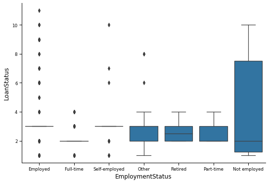

```python
box_plot(['EmploymentStatus'])
```

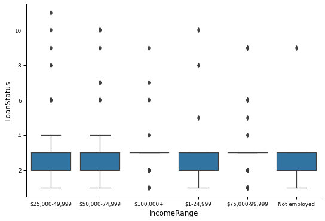

```python
box_plot(['IncomeRange'])
```

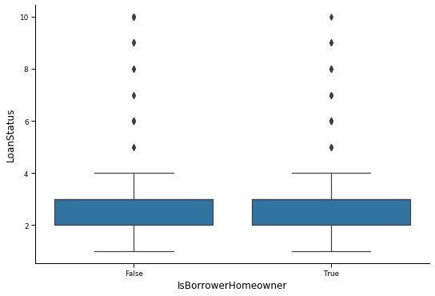

```python
box_plot(['IsBorrowerHomeowner'])
```

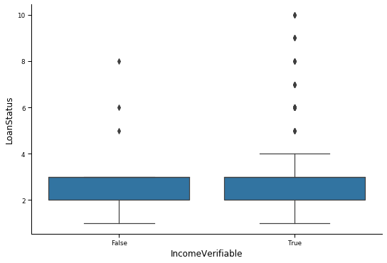

```python
box_plot(['IncomeVerifiable'])
```

the two plots are very similar, i think this feature doesn’t really affect the loan statues.

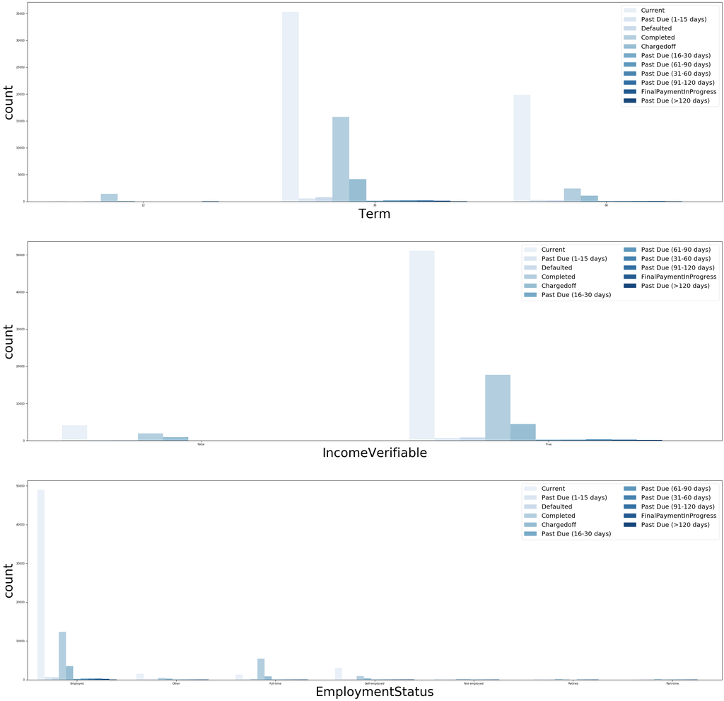

```python
#
def countplot():
    plt.figure(figsize = [40, 40])
    sns.set_context("paper", rc={"font.size":40,"axes.titlesize":40,"axes.labelsize":40})
    # subplot 1: Term vs LoanStatus
    plt.subplot(3, 1, 1)
    sns.countplot(data = df_clean, x = 'Term', hue = 'LoanStatus', palette = 'Blues')
    plt.legend(prop={'size': 20})
    # subplot 2: IncomeVerifiable vs LoanStatus
    ax = plt.subplot(3, 1, 2)
    sns.countplot(data = df_clean, x = 'IncomeVerifiable', hue = 'LoanStatus', palette = 'Blues')
    ax.legend(ncol = 2,prop={'size': 20}) # re-arrange legend to reduce overlapping

    # subplot 3: EmploymentStatus vs LoanStatus
    ax = plt.subplot(3, 1, 3)
    sns.countplot(data = df_clean, x = 'EmploymentStatus', hue = 'LoanStatus', palette = 'Blues')
    ax.legend(loc = 1, ncol = 2,prop={'size': 20}) # re-arrange legend to remove overlapping

    plt.show()
countplot()
```

This plot is very helpful, in the first plot I can see that most borrowers are in the 36-month term, and that a large number completed their loan.

In the second plot I see that the data is very imbalance, most of borrowers have a verified income

In the third plot I can see that most borrowers are employed and there is a large number of completed loans

```python
#print("Correlation between Loan status and LoanOriginalAmount : ",data_corr.loc['LoanStatus','LoanOriginalAmount'])
#print("Correlation between Loan status and Term : ",data_corr.loc['LoanStatus','Term'])
```

### Did you observe any interesting relationships between the other features (not the main feature(s) of interest)?

> **Yes**, a relationship between (term and loanorginamount), (prosperscore and incomeverifiable), (prosperscore and loanorginamount) (isBorrwerHomeOwner and loanorginamount)was observed. and the strongest one was between term and LoanOrginlAmount but it is not that strong. and as I said I did the same thing but i convertertd loan status into numbers and see how it corrlete with them.

## Multivariate Exploration

> In this part i will explor prosperscore and loanorginamount, with other fetuers

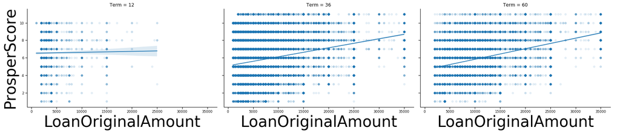

```python
g=sns.FacetGrid(data=df_clean, aspect=1.5, height=5, col='Term')
sns.set_context("paper", rc={"font.size":12,"axes.titlesize":12,"axes.labelsize":12})
g.map(sns.regplot, 'LoanOriginalAmount', 'ProsperScore', scatter_kws={'alpha':0.1});

g.add_legend();
```

Term effect the relationship between ProsperScore and LoanOriginalAmount

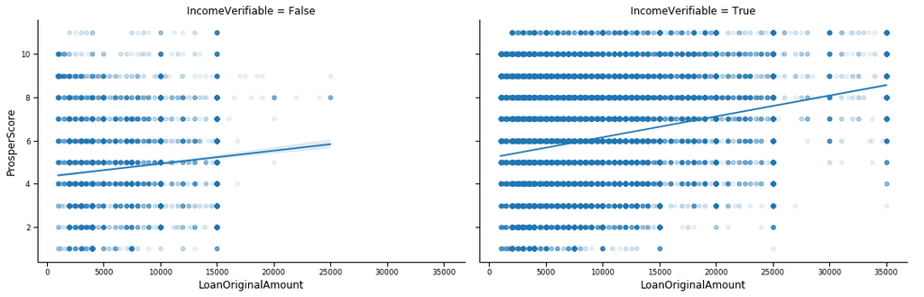

```python
g=sns.FacetGrid(data=df_clean, aspect=1.5, height=5, col='IncomeVerifiable')
sns.set_context("paper", rc={"font.size":12,"axes.titlesize":12,"axes.labelsize":12})
g.map(sns.regplot, 'LoanOriginalAmount', 'ProsperScore', scatter_kws={'alpha':0.1});

g.add_legend();
```

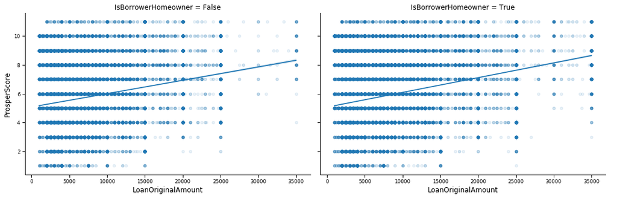

```python
g=sns.FacetGrid(data=df_clean, aspect=1.5, height=5, col='IsBorrowerHomeowner')
g.map(sns.regplot, 'LoanOriginalAmount', 'ProsperScore', scatter_kws={'alpha':0.1});
sns.set_context("paper", rc={"font.size":12,"axes.titlesize":12,"axes.labelsize":12})
g.add_legend();
```

IsBorrowerHomeowner dosent effect the relationship between ProsperScore and LoanOriginalAmount

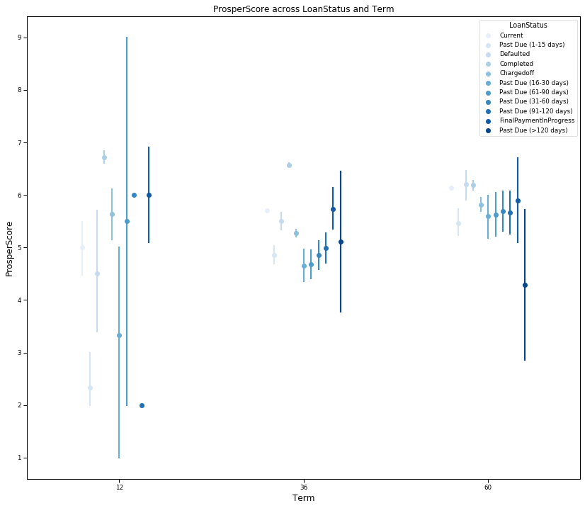

```python
fig = plt.figure(figsize = [14,12])
ax = sns.pointplot(data = df_clean, x = 'Term', y = 'ProsperScore', hue = 'LoanStatus',
           palette = 'Blues', linestyles = '', dodge = 0.4)
plt.title('ProsperScore across LoanStatus and Term')
plt.show();
```

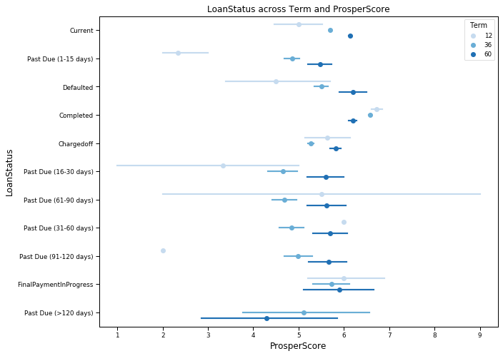

```python
fig = plt.figure(figsize = [10,8])
ax = sns.pointplot(data = df_clean, y = 'LoanStatus', x = 'ProsperScore', hue = 'Term',
           palette = 'Blues', linestyles = '', dodge = 0.4)
plt.title('LoanStatus across Term and ProsperScore')
plt.show();
```

### Talk about some of the relationships you observed in this part of the investigation. Were there features that strengthened each other in terms of looking at your feature(s) of interest?

> - Term effect the relationship between ProsperScore and LoanOriginalAmount
> - The completd loan statuse got a highe prosperscore, less risky, which is related.

### Ref:

- https://stackoverflow.com/questions/7125009/how-to-change-legend-size-with-matplotlib-pyplot
- https://seaborn.pydata.org/tutorial/categorical.html#categorical-tutorial
- https://docs.google.com/spreadsheets/d/1gDyi_L4UvIrLTEC6Wri5nbaMmkGmLQBk-Yx3z0XDEtI/edit#gid=0
- Diamonds Data Exploration Example